# Finite Markov Chains

Jing Fang and Shihui Ma

# Overview

# Overview

- Markov chains are one of the most useful classes of stochastic processes
- Attributes:
  - simple, flexible and supported by many elegant theoretical results
  - valuable for building intuition about random dynamic models
  - very useful in their own right

# Overview

- You will find them in many of the workhorse models of economics and finance
- In this lecture we review some of the theory of Markov chains
- We will also introduce some of the great routines for working with Markov chains available in QuantEcon
- Prerequisite knowledge is basic probability and linear algebra

# Definitions

# Stochastic Matrices

- A *stochastic matrix* (or *Markov matrix*) is an $n\times n$ square matrix $P=P[s,s']$ such that
  1. each element $P[s,s']$ is nonnegative, and
  2. each row $P[s,.]$ sums to one
- Let $S={0,...,n−1}$
- Each row $P[s,.]$ can be regarded as a distribution (probability mass function) on $S$
- It is not difficult to check that if $P$ is a stochastic matrix, then so is the $k$-th power $P^k$ for all $k\in\mathbb{N}$

# Markov Chains

- There is a close connection between stochastic matrices and Markov chains
- A *Markov chain* $\{X_t\}$ on $S$ is a stochastic process on $S$ that has the *Markov property*
- This means that, for any date $t$ and any state $s'\in S$,
  $$\mathbb{P}\{X_{t+1}=s'|X_t\}=\mathbb{P}\{X_{t+1}=s'|X_t,X_{t−1},...\}$$
- In other words, knowing the current state is enough to understand probabilities for future states

# Markov Chains

- In particular, the dynamics of a Markov chain are fully determined by the set of values
  $$P[s,s']=\mathbb{P}\{X_{t+1}=s'|X_t=s\}\:(s,s'\in S)$$
- By construction,
  - $P[s,s']$ is the probability of going from $s$ to $s'$ in one unit of time (one step)
  - $P[s,.]$ is the conditional distribution of $X_{t+1}$ given $X_t=s$
- It’s clear that $P$ is a stochastic matrix

# Markov Chains

- Conversely, if we take a stochastic matrix $P$, we can generate a Markov chain $\{X_t\}$ as follows:
  - draw $X_0$ from some specified distribution
  - for $t=0,1,...,$
    - draw $X_{t+1}$ from $P[X_t,.]$

# Example 1

- Consider a worker who, at any given time $t$, is either unemployed (state 0) or employed (state 1)
- Suppose that, over a one month period,
  1. An employed worker loses her job and becomes unemployed with probability $\beta\in(0,1)$
  2. An unemployed worker finds a job with probability $\alpha\in(0,1)$
- In terms of a stochastic matrix, this tells us that $P[0,1]=\alpha$ and $P[1,0]=\beta$, or
  $$P=\begin{pmatrix}
  1-\alpha & \alpha \\
  \beta & 1-\beta
  \end{pmatrix}$$

# Example 1

- Once we have the values $\alpha$ and $\beta$, we can address a range of questions, such as
  - What is the average duration of unemployment?
  - Over the long-run, what fraction of time does a worker find herself unemployed?
  - Conditional on employment, what is the probability of becoming unemployed at least once over the next 12 months?
  - Etc.

# Example 2

- Using US unemployment data, Hamilton estimated the stochastic matrix
  $$P=\begin{pmatrix}
  0.971 & 0.029 & 0 \\
  0.145 & 0.778 & 0.077\\
  0 & 0.508 & 0.492
  \end{pmatrix}$$
  where
  - the frequency is monthly
  - the first state represents “normal growth”
  - the second state represents “mild recession”
  - the third state represents “severe recession”

# Example 2

- For example, the matrix tells us that when the state is normal growth, the state will again be normal growth next month with probability 0.97
- In general, large values on the main diagonal indicate persistence in the process $\{X_t\}$

# Example 2

- This Markov process can also be represented as a directed graph, with edges labeled by transition probabilities

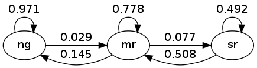

- Here “ng” is normal growth, “mr” is mild recession, etc.

# Simulation

# Simulation

- One of the most natural ways to answer questions about Markov chains is to simulate them
- Nice functionality for simulating Markov chains exists in QuantEcon
- This is probably what you should use in applications, since it’s is efficient and bundled with lots of other useful routines for handling Markov chains
- However, it’s also a good exercise to roll our own routines - let’s do that first and then come back to the methods in QuantEcon

# Rolling our own

- To simulate a Markov chain, we need its stochastic matrix $P$ and either an initial state or a probability distribution $\psi$ for initial state to be drawn from
- The Markov chain is then constructed as discussed above. To repeat:
  1. At time $t=0$, the $X_0$ is set to some fixed state or chosen from $\psi$
  2. At each subsequent time $t$, the new state $X_{t+1}$ is drawn from $P[X_t,.]$

# Rolling our own

- In order to implement this simulation procedure, we need a method for generating draws from a discrete distributions
- For this task we’ll use DiscreteRV from QuantEcon

```python
from quantecon import DiscreteRV
psi = (0.1, 0.9)           # Probabilities over sample space {0, 1}
d = DiscreteRV(psi)
d.draw(5)
```

# Rolling our own

- We’ll write our code as a function that takes the following three arguments
  - A stochastic matrix $P$
  - An initial state `init`
  - A positive integer `sample_size` representing the length of the time series the function should return

# Rolling our own

```python
import numpy as np
import quantecon as qe
def mc_sample_path(P, init=0, sample_size=1000):
    # === make sure P is a NumPy array === #
    P = np.asarray(P)
    # === allocate memory === #
    X = np.empty(sample_size, dtype=int)
    X[0] = init
    # === convert each row of P into a distribution === #
    # In particular, P_dist[i] = the distribution corresponding to P[i,:]
    n = len(P)
    P_dist = [qe.DiscreteRV(P[i,:]) for i in range(n)]
    # === generate the sample path === #
    for t in range(sample_size - 1):
        X[t+1] = P_dist[X[t]].draw()
    return X
```

# Rolling our own

- Let’s see how it works using the small matrix
  $$P=\begin{pmatrix}
  0.4 & 0.6 \\
  0.2 & 0.8
  \end{pmatrix}$$
- As we’ll see later, for a long series drawn from `P`, the fraction of the sample that takes value 0 will be about 0.25

```python
P = [[0.4, 0.6], [0.2, 0.8]]
X = mc_sample_path(P, sample_size=100000)
np.mean(X == 0)
```

# Using QuantEcon’s Routines

- As discussed above, QuantEcon has very nice routines for handling Markov chains, inluding simulation
- Here’s an illustration using the same `P` as the preceding example

```python
import numpy as np
import quantecon as qe
P = [[0.4, 0.6], [0.2, 0.8]]
mc = qe.MarkovChain(P)
X = mc.simulate(ts_length=1000000)
np.mean(X == 0)
```

# Using QuantEcon’s Routines

- In fact the QuantEcon routine is JIT compiled and much faster
- Because it’s JIT compiled the first run takes a bit longer - the function has to be compiled and stored in memory

```python
%timeit mc_sample_path(P, sample_size=1000000) # our version

%timeit mc.simulate(ts_length=1000000) # qe version
```

# Marginal Distributions

# Marginal Distributions

- Suppose that
  1. $\{X_t\}$ is a Markov chain with stochastic matrix $P$
  2. the distribution of $X_t$ is known to be $\psi_t$
- What then is the distribution of $X_{t+1}$, or, more generally, of $X_{t+m}$?

# Solution

- Let $\psi_t$ be the distribution of $X_t$ for $t=0,1,2,...$
- Our first aim is to find $\psi_{t+1}$ given $\psi_t$ and $P$
- To begin, pick any $s'\in S$
- Using the law of total probability, we can decompose the probability that $X_{t+1}=s'$ as follows:
  $$\mathbb{P}\{X_{t+1}=s'\}=\sum_{s\in S}\mathbb{P}\{X_{t+1}=s'|X_t=s\} \cdot \mathbb{P}\{X_{t}=s\}$$
- In words, to get the probability of being at $s'$ tomorrow, we account for all ways this can happen and sum their probabilities

# Solution

- Rewriting this statement in terms of marginal and conditional probabilities gives
  $$\psi_{t+1}[s']=\sum_{s\in S} P[s,s']\psi_{t}[s]$$
- There are $n$ such equations, one for each $s'\in S$
- If we think of $\psi_{t+1}$ and $\psi_{t}$ as *row vectors* (as is traditional), these $n$ equations are summarized by the matrix expression
  $$\psi_{t+1}=\psi_t P$$
- In other words, to move the distribution forward one unit of time, we postmultiply by $P$

# Solution

- By repeating this $m$ times we move forward $m$ steps into the future
- Hence, iterating on this equation, the expression $\psi_{t+m}=\psi_t P^m$ is also valid - here $P^m$ is the $m$-th power of $P$
- As a special case, we see that if $\psi_0$ is the initial distribution from which $X_0$ is drawn, then $\psi_0 P^m$ is the distribution of $X_m$

# Solution

- This is very important, so let’s repeat it
  $$X_0\sim\psi_0 \Rightarrow X_m\sim\psi_0 P^m$$
  and more generally,
  $$X_t\sim\psi_t \Rightarrow X_t+m\sim\psi_t P^m$$

# Multiple Step Transition Probabilities

- We know that the probability of transitioning from $s$ to $s'$ in one step is $P[s,s']$
- It turns out that that the probability of transitioning from $s$ to $s'$ in $m$ steps is $P^m[s,s']$, the $[s,s']$-th element of the $m$-th power of $P$
- To see why, consider again the above results, but now with $\psi_t$ putting all probability on state $s$

# Multiple Step Transition Probabilities

- If we regard $\psi_t$ as a vector, it is a vector with 1 in the $s$-th position and zero elsewhere
- Inserting this into the above result, we see that, conditional on $X_t=s$, the distribution of $X_{t+m}$ is the $s$-th row of $P^m$
- In particular
  $$\mathbb{P}\{X_{t+m}=s'\}=P^m[s,s']=[s,s']-\text{th element of } P^m$$

# Example: Probability of Recession

- Recall the stochastic matrix $P$ for recession and growth considered above
- Suppose that the current state is unknown - perhaps statistics are available only at the end of the current month
- We estimate the probability that the economy is in state s to be $\psi[s]$

# Example: Probability of Recession

- The probability of being in recession (state 1 or state 2) in 6 months time is given by the inner product
  $$\psi P^6\cdot\begin{pmatrix}0\\1\\1\end{pmatrix}$$

# Example 2: Cross-Sectional Distributions

- Recall our model of employment / unemployment dynamics for a given worker discussed above
- Consider a large (i.e., tending to infinite) population of workers, each of whose lifetime experiences are described by the specified dynamics, independently of one another
- Let $\psi$ be the current *cross-sectional* distribution over {0,1}
  - For example, $\psi[0]$ is the unemployment rate

# Example 2: Cross-Sectional Distributions

- The cross-sectional distribution records the fractions of workers employed and unemployed at a given moment
- The same distribution also describes the fractions of a particular worker’s career spent being employed and unemployed, respectively

# Irreducibility and Aperiodicity

# Irreducibility

- Let $P$ be a fixed stochastic matrix
- Two states $s$ and $s'$ are said to *communicate* with each other if there exist positive integers $j$ and $k$ such that
  $$P^j[s,s']>0 \text{ and } P^k[s',s]>0$$
- This means precisely that
  - state $s$ can be reached eventually from state $s'$, and
  - state $s'$ can be reached eventually from state $s$
- The stochastic matrix $P$ is called *irreducible* if all states communicate; that is, if $s$ and $s'$ communicate for all $s,s'$ in $S\times S$

# Irreducibility

- For example, consider the following transition probabilities for wealth of a ficticious set of households

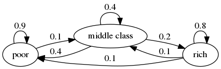

# Irreducibility

- We can translate this into a stochastic matrix, putting zeros where there’s no edge between nodes
  $$P=\begin{pmatrix}
  0.9 & 0.1 & 0 \\
  0.4 & 0.4 & 0.2 \\
  0.1 & 0.1 & 0.8
  \end{pmatrix}$$
- It’s clear from the graph that this stochastic matrix is irreducible: we can reach any state from any other state eventually

# Irreducibility

- We can also test this using QuantEcon’s MarkovChain class

```python
import quantecon as qe
P = [[0.9, 0.1, 0.0],
     [0.4, 0.4, 0.2],
     [0.1, 0.1, 0.8]]
mc = qe.MarkovChain(P)
mc.is_irreducible
```

# Irreducibility

- Here’s a more pessimistic scenario, where the poor are poor forever

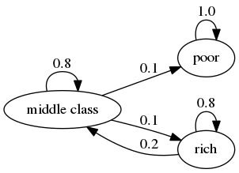

# Irreducibility

- This stochastic matrix is not irreducible, since, for example, `rich` is not accessible from poor

```python
P = [[1.0, 0.0, 0.0],
     [0.1, 0.8, 0.1],
     [0.0, 0.2, 0.8]]
mc = qe.MarkovChain(P)
mc.is_irreducible
```

- We can also determine the “communication classes”

```python
mc.communication_classes
```

- It might be clear to you already that irreducibility is going to be important in terms of long run outcomes
- For example, poverty is a life sentence in the second graph but not the first

# Aperiodicity

- Loosely speaking, a Markov chain is called periodic if it cycles in a predictible way and aperiodic otherwise
- Here’s a trivial example with three states

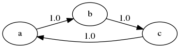

# Aperiodicity

- The chain cycles with period 3

```python
P = [[0, 1, 0],
     [0, 0, 1],
     [1, 0, 0]]
mc = qe.MarkovChain(P)
mc.period
```

- More formally, the period of a state $s$ is the greatest common divisor of the set of integers
  $$D(s)=\{j\geq 1:P^j[s,s]>0\}$$
- In the last example, $D(s)=\{3,6,9,...\}$ for every state $s$, so the period is 3

# Aperiodicity

- A stochastic matrix is called *aperiodic* if the period of every state is 1, and *periodic* otherwise
- For example, the stochastic matrix associated with the transition probabilities below is periodic because, for example, state $a$ has period 2

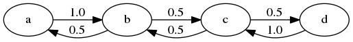

# Aperiodicity

- We can confirm that the stochastic matrix is periodic as follows

```python
import quantecon as qe
P = [[0.0, 1.0, 0.0, 0.0],
     [0.5, 0.0, 0.5, 0.0],
     [0.0, 0.5, 0.0, 0.5],
     [0.0, 0.0, 1.0, 0.0]]
mc = qe.MarkovChain(P)
mc.period

mc.is_aperiodic
```

# Stationary Distributions

# Stationary Distributions

- As seen before, we can shift probabilities forward one unit of time via postmultiplication by $P$
- Some distributions are invariant under this updating process

```python
P = np.array([[.4, .6], [.2, .8]])  # after import numpy as np
psi = (0.25, 0.75)
np.dot(psi, P)
```

- Such distributions are called *stationary*, or *invariant*

# Stationary Distributions

- Formally, a distribution $\psi^*$ on $S$ is called *stationary* for $P$ if $\psi^*=\psi^*P$
- From this equality we immediately get $\psi^*=\psi^*P^t$ for all $t$
- This tells us an important fact: If the distribution of $X_0$ is a stationary distribution, then $X_t$ will have this same distribution for all t

# Stationary Distributions

- Hence stationary distributions have a natural interpretation as stochastic steady states
- Mathematically, a stationary distribution is just a fixed point of $P$ when $P$ is thought of as the map $\psi\mapsto\psi P$ from (row) vectors to (row) vectors
- **Theorem** Every stochastic matrix P has at least one stationary distribution
- (We are assuming here that the state space $S$ is finite; if not more assumptions are required)
- For a proof of this result you can apply [Brouwer’s fixed point theorem](https://en.wikipedia.org/wiki/Brouwer_fixed-point_theorem)

# Stationary Distributions

- There may in fact be many stationary distributions corresponding to a given stochastic matrix $P$
  - For example, if $P$ is the identity matrix, then all distributions are stationary
- Since stationary distributions are long run equilibria, to get uniqueness we require that initial conditions are not infinitely persistent
- Infinite persistence of initial conditions occurs if certain regions of the state space cannot be accessed from other regions, which is the opposite of irreducibility

# Stationary Distributions

- This gives some intuition for the following fundamental theorem
- **Theorem**. If $P$ is both aperiodic and irreducible, then
  1. $P$ has exactly one stationary distribution $\psi^*$
  2. For any initial distribution $\psi_0$, we have $\left\|\psi_0P^t−\psi^*\right\|\rightarrow 0$ as $t\rightarrow\infty$
- For a proof, see, for example, theorem 5.2 of “Finite Markov chains and algorithmic applications” by Olle Haggstrom, volume 52, Cambridge University Press, 2002.

# Stationary Distributions

- (Note that part 1 of the theorem requires only irreducibility, whereas part 2 requires both irreducibility and aperiodicity)
- One easy sufficient condition for aperiodicity and irreducibility is that every element of P is strictly positive

# Example

- Recall our model of employment / unemployment dynamics for a given worker discussed above
- Assuming $\alpha\in(0,1)$ and $\beta\in(0,1)$, the uniform ergodicity condition is satisfied
- Let $\psi^*=(p,1−p)$ be the stationary distribution, so that p corresponds to unemployment (state 0)

# Example

- Using $\psi^*=\psi^*P$ and a bit of algebra yields
  $$p=\frac{\beta}{\alpha+\beta}$$
- This is, in some sense, a steady state probability of unemployment
- Not surprisingly it tends to zero as $\beta\rightarrow 0$, and to one as $\alpha\rightarrow 0$

# Calculating Stationary Distributions

- As discussed above, a given Markov matrix $P$ can have many stationary distributions
- That is, there can be many row vectors $\psi$ such that $\psi=\psi P$
- In fact if $P$ has two distinct stationary distributions $\psi_1,\psi_2$ then it has infinitely many, since in this case, as you can verify,
  $$\psi_3=\lambda\psi_1+(1−\lambda)\psi_2$$
  is a stationary distribuiton for $P$ for any $\lambda\in[0,1]$

# Calculating Stationary Distributions

- If we restrict attention to the case where only one stationary distribution exists, one option for finding it is to try to solve the linear system $\psi(I_n−P)=0$ for $\psi$, where $I_n$ is the $n\times n$ identity
- But the zero vector solves this equation

# Calculating Stationary Distributions

- Hence we need to impose the restriction that the solution must be a probability distribution
- A suitable algorithm is implemented in QuantEcon - the next code block illustrates

```python
import quantecon as qe
P = [[0.4, 0.6], [0.2, 0.8]]
mc = qe.MarkovChain(P)
mc.stationary_distributions
```

- The stationary distribution is unique

# Convergence to Stationarity

- Part 2 of the Markov chain convergence theorem stated above tells us that the distribution of $X_t$ converges to the stationary distribution regardless of where we start off
- This adds considerable weight to our interpretation of $\psi^*$ as a stochastic steady state
- The convergence in the theorem is illustrated in the next figure

# Convergence to Stationarity

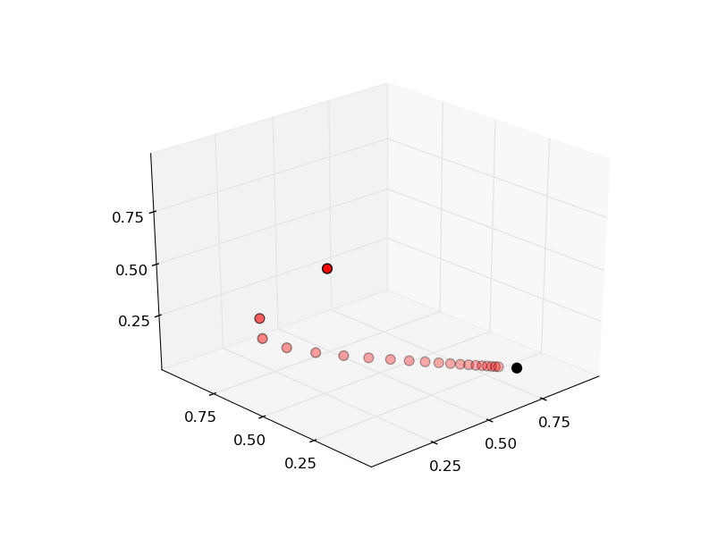

# Convergence to Stationarity

- Here
  - $P$ is the stochastic matrix for recession and growth considered above
  - The highest red dot is an arbitrarily chosen initial probability distribution $\psi$, represented as a vector in $\mathbb{R}^3$
  - The other red dots are the distributions $\psi P^t$ for $t=1,2,...$
  - The black dot is $\psi^*$

# Ergodicity

# Ergodicity

- Under irreducibility, yet another important result obtains: For all $s\in S$,
  $$\frac{1}{n}\sum_{t=1}^n 1\{X_t=s\}\rightarrow\psi^*[s]\text{ as } n\rightarrow\infty$$
- Here
  - $1\{X_t=s\}=1$ if $X_t=s$ and zero otherwise
  - convergence is with probability one
  - the result does not depend on the distribution (or value) of $X_0$

# Ergodicity

- The result tells us that the fraction of time the chain spends at state s converges to $\psi^*[s]$ as time goes to infinity
- This gives us another way to interpret the stationary distribution. That is, the convergence is a special case of a law of large numbers result for Markov chains

# Example

- Recall our cross-sectional interpretation of the employment / unemployment model discussed above
- Assume that $\alpha\in(0,1)$ and $\beta\in(0,1)$, so that irreducibility and aperiodicity both hold
- We saw that the stationary distribution is $(p,1−p)$, where
  $$p=\frac{\beta}{\alpha+\beta}$$

# Example

- In the cross-sectional interpretation, this is the fraction of people unemployed
- In view of our latest (ergodicity) result, it is also the fraction of time that a worker can expect to spend unemployed
- Thus, in the long-run, cross-sectional averages for a population and time-series averages for a given person coincide

# Computing Expectations

# Computing Expectations

- We are interested in computing expectations of the form
  $$\mathbb{E}[h(X_t)]$$
  and conditional expectations such as
  $$\mathbb{E}[h(X_{t+k})|X_t=s]$$
  where
  - $\{X_t\}$ is a Markov chain generated by $n\times n$ stochastic matrix $P$
  - $h:S\rightarrow\mathbb{R}$ is a given function

# Computing Expectations

- The unconditional expectation is easy: We just need to sum over the distribution of $X_t$
- That is, we take
  $$\mathbb{E}[h(X_t)]=\sum_{s\in S}(\psi P^t)[s]h[s]$$
  where $\psi$ is the distribution of $X_0$
- In this setting it’s traditional to regard $h$ as a column vector, in which case the expression can be rewritten more simply as
  $$\mathbb{E}[h(X_t)]=\psi P^th$$

# Computing Expectations

- As for the conditional expectation, we need to sum over the conditional distribution of $X_{t+k}$ given $X_t=s$
- We already know that this is $P^k[s,.]$, so
  $$\mathbb{E}[h(X_{t+k})|X_t=s]=(P^kh)[s]$$
- The vector $P^kh$ stores the conditional expectation $\mathbb{E}[h(X_{t+k})|X_t=s]$ over all $s$

# Expectations of Geometric Sums

- Sometimes we also want to compute expectations of a geometric sum, such as $\sum_t\beta^t h(X_t)$
- In view of the preceding discussion, this is
  $$\mathbb{E}[\sum_{j=0}^\infty \beta^jh(X_{t+j})|X_t=s]=[(I-\beta P)^{-1}h][s]$$
  where
  $$(I−\beta P)^{−1}=I+\beta P+\beta^2P^2+...$$
- Premultiplication by $(I−\beta P)^{−1}$ amounts to “applying the *resolvent operator*“

# Exercises

# Exercises 1

- According to the discussion immediately above, if a worker’s employment dynamics obey the stochastic matrix
  $$P=\begin{pmatrix}
  1-\alpha & \alpha \\
  \beta & 1-\beta
  \end{pmatrix}$$
  with $\alpha\in(0,1)$ and $\beta\in(0,1)$ then, in the long-run, the fraction of time spent unemployed will be
  $$p=\frac{\beta}{\alpha+\beta}$$

# Exercises 1

- In other words, if $\{X_t\}$ represents the Markov chain for employment, then $\bar{X}_n\rightarrow p$ as $n\rightarrow\infty$, where
  $$\bar{X}_n=\frac{1}{n}\sum_{t=1}^n 1\{X_t=0\}$$
- Your exercise is to illustrate this convergence
- First,
  - generate one simulated time series $\{X_t\}$ of length 10,000, starting at $X_0=0$
  - plot $\bar{X}_n−p$ against $n$, where $p$ is as defined above
- Second, repeat the first step, but this time taking $X_0=1$

# Exercises 1

- In both cases, set $\alpha=\beta=0.1$
- The result should look something like the following - modulo randomness, of course

# Exercises 1

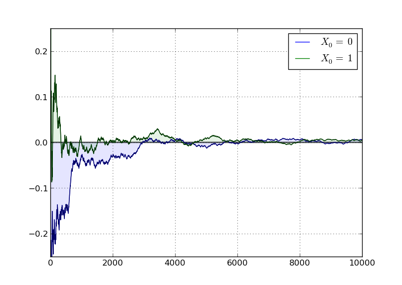

# Exercise 2

- A topic of interest for economics and many other disciplines is *ranking*
- Let’s now consider one of the most practical and important ranking problems - the rank assigned to web pages by search engines
- To understand the issue, consider the set of results returned by a query to a web search engine

# Exercise 2

- For the user, it is desirable to
  - receive a large set of accurate matches
  - have the matches returned in order, where the order corresponds to some measure of “importance”
- Ranking according to a measure of importance is the problem we now consider

# Exercise 2

- The methodology developed to solve this problem by Google founders Larry Page and Sergey Brin is known as PageRank
- To illustrate the idea, consider the following diagram

# Exercise 2

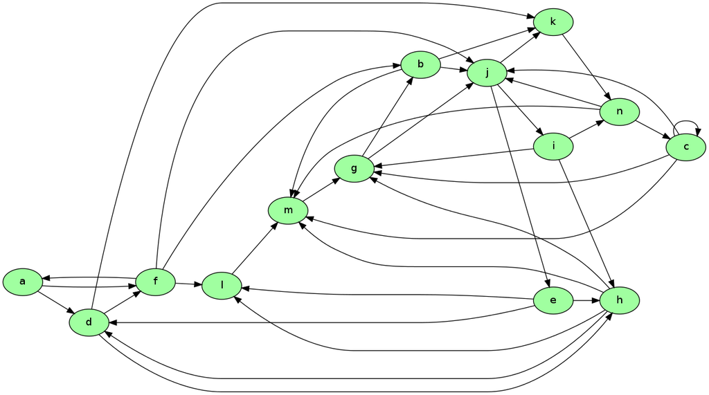

# Exercise 2

- Imagine that this is a miniature version of the WWW, with
  - each node representing a web page
  - each arrow representing the existence of a link from one page to another
- Now let’s think about which pages are likely to be important, in the sense of being valuable to a search engine user
- One possible criterion for importance of a page is the number of inbound links - an indication of popularity

# Exercise 2

- By this measure, `m` and `j` are the most important pages, with 5 inbound links each
- However, what if the pages linking to m, say, are not themselves important?
- Thinking this way, it seems appropriate to weight the inbound nodes by relative importance
- The PageRank algorithm does precisely this

# Exercise 2

- A slightly simplified presentation that captures the basic idea is as follows
- Letting $j$ be (the integer index of) a typical page and $r_j$ be its ranking, we set
  $$r_j=\sum_{i\in L_j}\frac{r_i}{l_i}$$
  where
  - $l_i$ is the total number of outbound links from $i$
  - $L_j$ is the set of all pages $i$ such that $i$ has a link to $j$
- This is a measure of the number of inbound links, weighted by their own ranking (and normalized by $1/l_i$)

# Exercise 2

- There is, however, another interpretation, and it brings us back to Markov chains
- Let $P$ be the matrix given by $P[i,j]=1\{i\rightarrow j\}/l_i$ where $1\{i\rightarrow j\}=1$ if $i$ has a link to $j$ and zero otherwise
- The matrix $P$ is a stochastic matrix provided that each page has at least one link

# Exercise 2

- With this definition of $P$ we have
  $$r_j=\sum_{i\in L_j}\frac{r_i}{l_i}=\sum_{\text{all }i} 1\{i\rightarrow j\}\frac{r_i}{l_i}=\sum_{\text{all }i} P[i,j]r_i$$
- Writing $r$ for the row vector of rankings, this becomes $r=rP$

# Exercise 2

- Hence $r$ is the stationary distribution of the stochastic matrix $P$
- Let’s think of $P[i,j]$ as the probability of “moving” from page $i$ to page $j$
- The value $P[i,j]$ has the interpretation
  - $P[i,j]=1/k$ if $i$ has $k$ outbound links, and $j$ is one of them
  - $P[i,j]=0$ if $i$ has no direct link to $j$

# Exercise 2

- Thus, motion from page to page is that of a web surfer who moves from one page to another by randomly clicking on one of the links on that page
- Here “random” means that each link is selected with equal probability
- Since $r$ is the stationary distribution of $P$, assuming that the uniform ergodicity condition is valid, we can interpret $r_j$ as the fraction of time that a (very persistent) random surfer spends at page j

# Exercise 2

- Your exercise is to apply this ranking algorithm to the graph pictured above, and return the list of pages ordered by rank
- The data for this graph is in the web_graph_data.txt file
- There is a total of 14 nodes (i.e., web pages), the first named `a` and the last named `n`
- A typical line from the file has the form `d->h`
- This should be interpreted as meaning that there exists a link from d to h

# Exercise 2

- To parse this file and extract the relevant information, you can use regular expressions
- The following code snippet provides a hint as to how you can go about this

```python
import re
re.findall('\w', 'x +++ y ****** z')  # \w matches alphanumerics

re.findall('\w', 'a ^^ b &&& $$ c')
```

- When you solve for the ranking, you will find that the highest ranked node is in fact `g`, while the lowest is `a`

# Exercise 3

- In numerical work it is sometimes convenient to replace a continuous model with a discrete one
- In particular, Markov chains are routinely generated as discrete approximations to AR(1) processes of the form
  $$y_{t+1}=\rho y_t+u_{t+1}$$
- Here $u_t$ is assumed to be iid and $N(0,\sigma^2_u)$
- The variance of the stationary probability distribution of $\{y_t\}$ is
  $$\sigma^2_y=\frac{\sigma^2_u}{1−\rho^2}$$

# Exercise 3

- Tauchen’s method is the most common method for approximating this continuous state process with a finite state Markov chain
- As a first step we choose
  - $n$, the number of states for the discrete approximation
  - $m$, an integer that parameterizes the width of the state space

# Exercise 3

- Next we create a state space $\{x_0,...,x_{n−1}\}\subset\mathbb{R}$ and a stochastic $n\times n$ matrix $P$ such that
  - $x_0=-m\sigma_y$
  - $x_{n-1}=m\sigma_y$
  - $x_{i+1}=x_i+s$ where $s=(x_{n-1}-x_0)/(n-1)$
  - $P[i,j]$ represents the probability of transitioning from $x_i$ to $x_j$
- Let $F$ be the cumulative distribution function of the normal distribution $N(0,\sigma^2_u)$

# Exercise 3

- The values $P[i,j]$ are computed to approximate the AR(1) process - omitting the derivation, the rules are as follows:
  1. If $j=0$, then set
     $$P[i,j]=P[i,0]=F(x_0−\rho x_i+s/2)$$
  2. If $j=n−1$, then set
     $$P[i,j]=P[i,n−1]=1−F(x_{n−1}−\rho x_i−s/2)$$
  3. Otherwise, set
     $$P[i,j]=F(x_j−\rho x_i+s/2)−F(x_j−\rho x_i−s/2)$$
- The exercise is to write a function `approx_markov(rho, sigma_u, m=3, n=7)` that returns $\{x_0,...,x_{n−1}\}\subset\mathbb{R}$ and $n\times n$ matrix $P$ as described above